# Session 6: Homework 3

Carlota_homework3

2020-09-10

# 1 Youth Risk Behavior Surveillance

Every two years, the Centers for Disease Control and Prevention conduct the [Youth Risk Behavior Surveillance System (YRBSS)](https://www.cdc.gov/healthyyouth/data/yrbs/index.htm) survey, where it takes data from high schoolers (9th through 12th grade), to analyze health patterns. You will work with a selected group of variables from a random sample of observations during one of the years the YRBSS was conducted.

## 1.1 Load the data

This data is part of the `openintro` textbook and we can load and inspect it. There are observations on 13 different variables, some categorical and some numerical. The meaning of each variable can be found by bringing up the help file:

?yrbss

```r
data(yrbss)
glimpse(yrbss)
```

```
## Rows: 13,583
## Columns: 13
## $ age                      <int> 14, 14, 15, 15, 15, 15, 15, 14, 15, 15, 15, …
## $ gender                   <chr> "female", "female", "female", "female", "fem…
## $ grade                    <chr> "9", "9", "9", "9", "9", "9", "9", "9", "9",…
## $ hispanic                 <chr> "not", "not", "hispanic", "not", "not", "not…
## $ race                     <chr> "Black or African American", "Black or Afric…
## $ height                   <dbl> NA, NA, 1.73, 1.60, 1.50, 1.57, 1.65, 1.88, …
## $ weight                   <dbl> NA, NA, 84.4, 55.8, 46.7, 67.1, 131.5, 71.2,…
## $ helmet_12m               <chr> "never", "never", "never", "never", "did not…
## $ text_while_driving_30d   <chr> "0", NA, "30", "0", "did not drive", "did no…
## $ physically_active_7d     <int> 4, 2, 7, 0, 2, 1, 4, 4, 5, 0, 0, 0, 4, 7, 7,…
## $ hours_tv_per_school_day  <chr> "5+", "5+", "5+", "2", "3", "5+", "5+", "5+"…
## $ strength_training_7d     <int> 0, 0, 0, 0, 1, 0, 2, 0, 3, 0, 3, 0, 0, 7, 7,…
## $ school_night_hours_sleep <chr> "8", "6", "<5", "6", "9", "8", "9", "6", "<5…
```

Before you carry on with your analysis, it’s is always a good idea to check with `skimr::skim()` to get a feel for missing values, summary statistics of numerical variables, and a very rough histogram.

## 1.2 Exploratory Data Analysis

You will first start with analyzing the `weight` of participants in kilograms. Using visualization and summary statistics, describe the distribution of weights. How many observations are we missing weights from?

```r
skimr::skim(yrbss)
```

Data summary

| Name | yrbss |
| --- | --- |
| Number of rows | 13583 |
| Number of columns | 13 |
| _______________________ |  |
| Column type frequency: |  |
| character | 8 |
| numeric | 5 |
| ________________________ |  |
| Group variables | None |

**Variable type: character**

| skim_variable | n_missing | complete_rate | min | max | empty | n_unique | whitespace |
| --- | --- | --- | --- | --- | --- | --- | --- |
| gender | 12 | 1.00 | 4 | 6 | 0 | 2 | 0 |
| grade | 79 | 0.99 | 1 | 5 | 0 | 5 | 0 |
| hispanic | 231 | 0.98 | 3 | 8 | 0 | 2 | 0 |
| race | 2805 | 0.79 | 5 | 41 | 0 | 5 | 0 |
| helmet_12m | 311 | 0.98 | 5 | 12 | 0 | 6 | 0 |
| text_while_driving_30d | 918 | 0.93 | 1 | 13 | 0 | 8 | 0 |
| hours_tv_per_school_day | 338 | 0.98 | 1 | 12 | 0 | 7 | 0 |
| school_night_hours_sleep | 1248 | 0.91 | 1 | 3 | 0 | 7 | 0 |

**Variable type: numeric**

| skim_variable | n_missing | complete_rate | mean | sd | p0 | p25 | p50 | p75 | p100 | hist |
| --- | --- | --- | --- | --- | --- | --- | --- | --- | --- | --- |
| age | 77 | 0.99 | 16.16 | 1.26 | 12.00 | 15.0 | 16.00 | 17.00 | 18.00 | ▁▂▅▅▇ |
| height | 1004 | 0.93 | 1.69 | 0.10 | 1.27 | 1.6 | 1.68 | 1.78 | 2.11 | ▁▅▇▃▁ |
| weight | 1004 | 0.93 | 67.91 | 16.90 | 29.94 | 56.2 | 64.41 | 76.20 | 180.99 | ▆▇▂▁▁ |
| physically_active_7d | 273 | 0.98 | 3.90 | 2.56 | 0.00 | 2.0 | 4.00 | 7.00 | 7.00 | ▆▂▅▃▇ |
| strength_training_7d | 1176 | 0.91 | 2.95 | 2.58 | 0.00 | 0.0 | 3.00 | 5.00 | 7.00 | ▇▂▅▂▅ |

High schooler’s weight and physical activities

```r
yrbss <- yrbss %>%
  mutate(physical_3plus = ifelse(physically_active_7d >= 3, "yes", "no"))

  yrbss_summary <- yrbss %>%
  filter(!is.na(physical_3plus)) %>%
  group_by(physical_3plus) %>%
  #Count the number of people with a positive physical 3plus
  #Quantify the proportion of people with a positive physical 3plus and       negative and store the value as prop
  summarise(count = n()) %>%
  mutate(prop= count/sum(count))
```

Can you provide a 95% confidence interval for the population proportion of high schools that are *NOT* active 3 or more days per week?

Make a boxplot of `physical_3plus` vs. `weight`. Is there a relationship between these two variables? What did you expect and why?

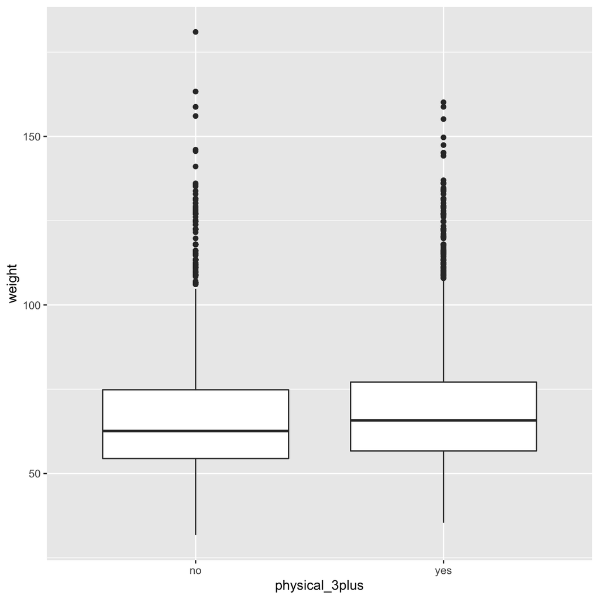

```r
#sum population
count_pop <- yrbss_summary  %>%  summarise(sum = sum(count))
#calculating the SE
se_pop <- sqrt(yrbss_summary$prop[1] * (1-yrbss_summary$prop[1])/count_pop)
#calculating the mean
mean_pop <- se_pop/sqrt(count_pop)
#t-critical value
t_critical <- qt(0.975, count_pop$sum-1)
lower_ci <- mean_pop - t_critical * se_pop
upper_ci <- mean_pop + t_critical * se_pop
yrbss_clean <- na.omit(yrbss)
boxplot_pop <- ggplot(data = yrbss_clean, aes(x = physical_3plus,y= weight)) + geom_boxplot()
boxplot_pop
```

## 1.3 Confidence Interval

Boxplots show how the medians of the two distributions compare, but we can also compare the means of the distributions using either a confidence interval or a hypothesis test. Note that when we calculate the mean/SD, etc weight in these groups using the mean function, we must ignore any missing values by setting the `na.rm = TRUE`.

```r
yrbss %>%
group_by(physical_3plus)%>%
  filter(!is.na(physical_3plus))%>%
  summarise(mean_weight=mean(weight,na.rm=TRUE),sd_weight=sd(weight,na.rm=TRUE),count=n(),
            se_weight=sd_weight/sqrt(count),t_critical=qt(0.975,count-1),margin_of_error=t_critical*se_weight,
            lower=mean_weight-margin_of_error,upper=mean_weight+margin_of_error)
```

```
## # A tibble: 2 x 9
##   physical_3plus mean_weight sd_weight count se_weight t_critical
##   <chr>                <dbl>     <dbl> <int>     <dbl>      <dbl>
## 1 no                    66.7      17.6  4404     0.266       1.96
## 2 yes                   68.4      16.5  8906     0.175       1.96
## # … with 3 more variables: margin_of_error <dbl>, lower <dbl>, upper <dbl>
```

There is an observed difference of about 1.77kg (68.44 - 66.67), and we notice that the two confidence intervals do not overlap. It seems that the difference is at least 95% statistically significant. Let us also conduct a hypothesis test.

## 1.4 Hypothesis test with formula

Write the null and alternative hypotheses for testing whether mean weights are different for those who exercise at least times a week and those who don’t.

```r
t.test(weight ~ physical_3plus, data = yrbss)
```

```
##
##  Welch Two Sample t-test
##
## data:  weight by physical_3plus
## t = -5, df = 7479, p-value = 9e-08
## alternative hypothesis: true difference in means is not equal to 0
## 95 percent confidence interval:
##  -2.42 -1.12
## sample estimates:
##  mean in group no mean in group yes
##              66.7              68.4
```

## 1.5 Hypothesis test with `infer`

Next, we will introduce a new function, `hypothesize`, that falls into the infer workflow. You will use this method for conducting hypothesis tests.

But first, we need to initialize the test, which we will save as `obs_diff`.

```r
obs_diff <- yrbss %>%
  specify(weight ~ physical_3plus) %>%
  calculate(stat = "diff in means", order = c("yes", "no"))
```

Notice how you can use the functions specify and calculate again like you did for calculating confidence intervals. Here, though, the statistic you are searching for is the difference in means, with the order being yes - no != 0.

After you have initialized the test, you need to simulate the test on the null distribution, which we will save as null.

```r
null_dist <- yrbss %>%
  specify(weight ~ physical_3plus) %>%
  hypothesize(null = "independence") %>%
  generate(reps = 1000, type = "permute") %>%
  calculate(stat = "diff in means", order = c("yes", "no"))
```

Here, `hypothesize` is used to set the null hypothesis as a test for independence, i.e., that there is no difference between the two population means. In one sample cases, the null argument can be set to *point* to test a hypothesis relative to a point estimate.

Also, note that the `type` argument within generate is set to permute, which is the argument when generating a null distribution for a hypothesis test.

We can visualize this null distribution with the following code:

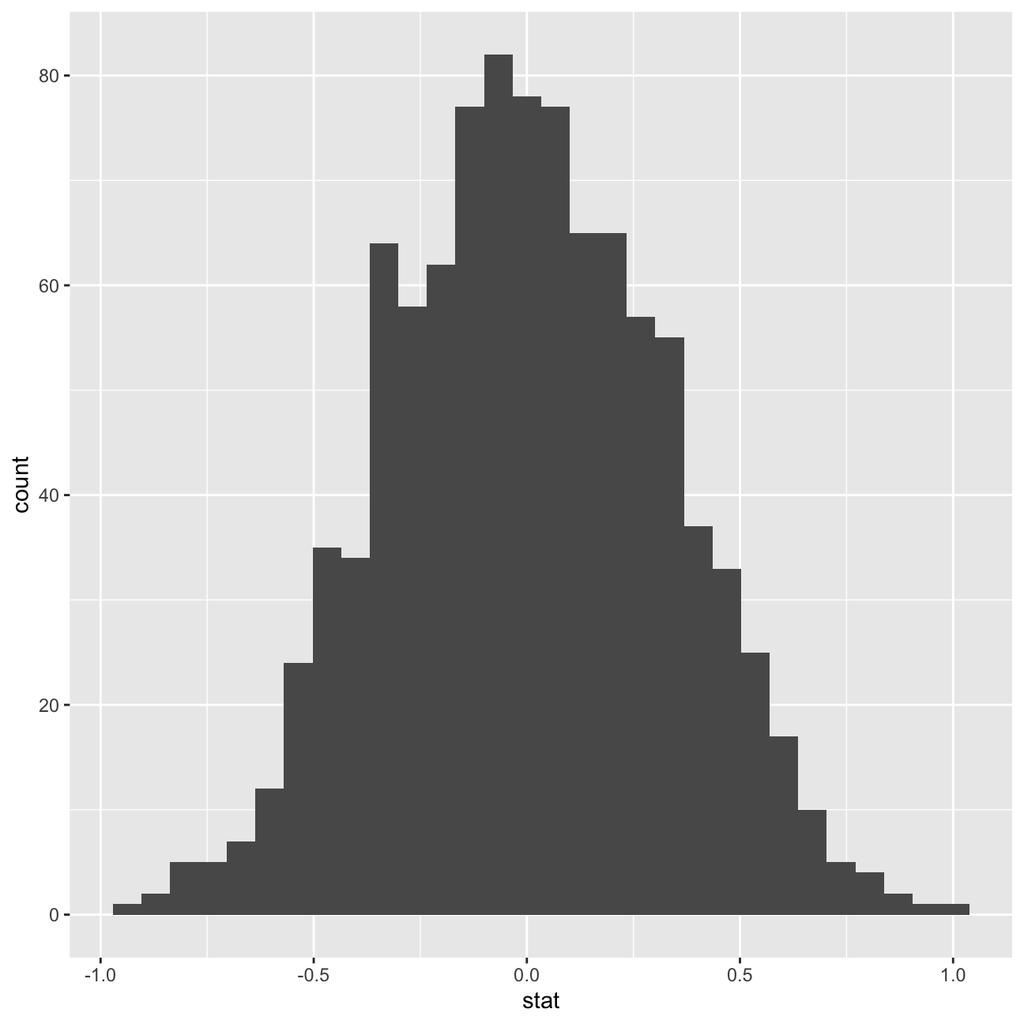

```r
ggplot(data = null_dist, aes(x = stat)) +
  geom_histogram()
```

Now that the test is initialized and the null distribution formed, we can visualise to see how many of these null permutations have a difference of at least `obs_stat` of 1.77?

We can also calculate the p-value for your hypothesis test using the function `infer::get_p_value()`.

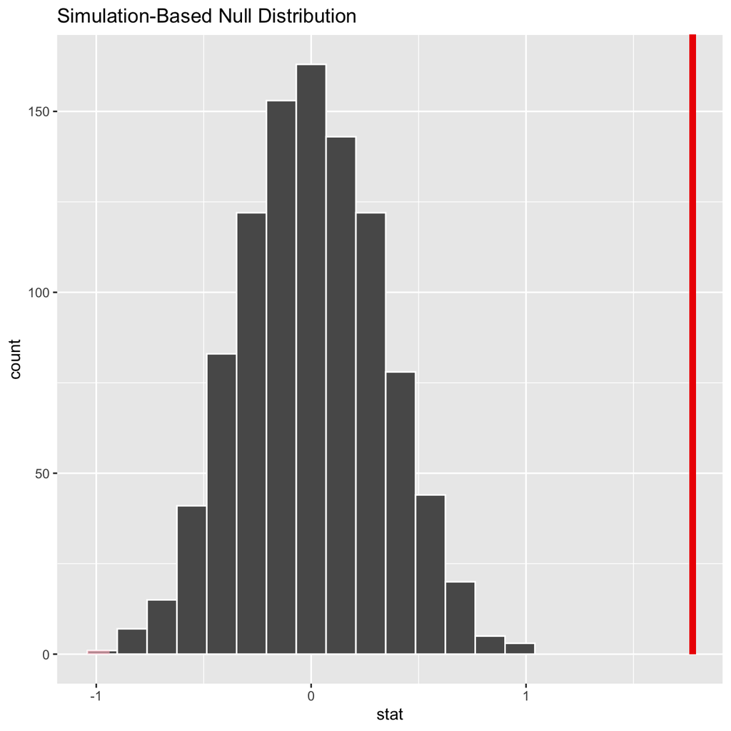

```r
null_dist %>% visualize() +
  shade_p_value(obs_stat = obs_diff, direction = "two-sided")
```

```r
null_dist %>%
  get_p_value(obs_stat = obs_diff, direction = "two_sided")
```

```
## # A tibble: 1 x 1
##   p_value
##     <dbl>
## 1       0
```

This the standard workflow for performing hypothesis tests.

# 2 IMDB ratings: Differences between directors

Recall the IMBD ratings data. I would like you to explore whether the mean IMDB rating for Steven Spielberg and Tim Burton are the same or not. I have already calculated the confidence intervals for the mean ratings of these two directors and as you can see they overlap.

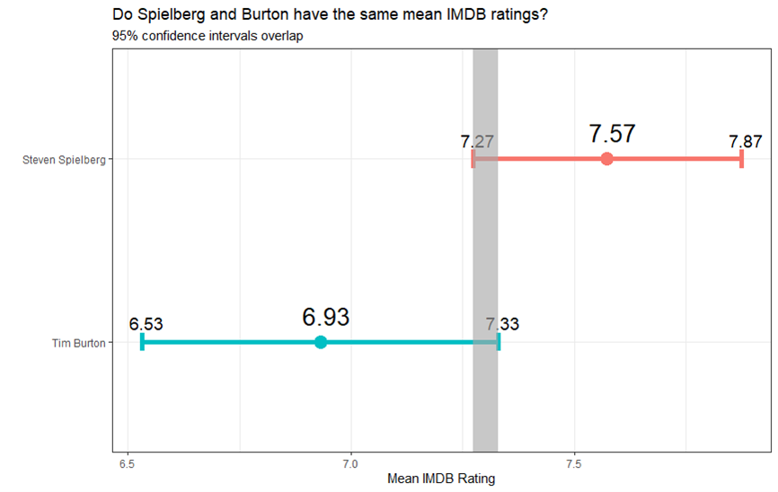

First, I would like you to reproduce this graph. You may find `geom_errorbar()` and `geom_rect()` useful.

In addition, you will run a hpothesis test. You should use both the `t.test` command and the `infer` package to simulate from a null distribution, where you assume zero difference between the two.

> Before anything, write down the null and alternative hypotheses, as well as the resulting test statistic and the associated t-stat or p-value. At the end of the day, what do you conclude?

You can load the data and examine its structure

```r
movies <- read_csv(here::here("data", "movies.csv"))
glimpse(movies)
```

```
## Rows: 2,961
## Columns: 11
## $ title               <chr> "Avatar", "Titanic", "Jurassic World", "The Aveng…
## $ genre               <chr> "Action", "Drama", "Action", "Action", "Action", …
## $ director            <chr> "James Cameron", "James Cameron", "Colin Trevorro…
## $ year                <dbl> 2009, 1997, 2015, 2012, 2008, 1999, 1977, 2015, 2…
## $ duration            <dbl> 178, 194, 124, 173, 152, 136, 125, 141, 164, 93, …
## $ gross               <dbl> 7.61e+08, 6.59e+08, 6.52e+08, 6.23e+08, 5.33e+08,…
## $ budget              <dbl> 2.37e+08, 2.00e+08, 1.50e+08, 2.20e+08, 1.85e+08,…
## $ cast_facebook_likes <dbl> 4834, 45223, 8458, 87697, 57802, 37723, 13485, 92…
## $ votes               <dbl> 886204, 793059, 418214, 995415, 1676169, 534658, …
## $ reviews             <dbl> 3777, 2843, 1934, 2425, 5312, 3917, 1752, 1752, 3…
## $ rating              <dbl> 7.9, 7.7, 7.0, 8.1, 9.0, 6.5, 8.7, 7.5, 8.5, 7.2,…
```

Your R code and analysis should go here. If you want to insert a blank chunk of R code you can just hit `Ctrl/Cmd+Alt+I`

```r
selected_directors <- movies %>%
  select(director,rating)%>%
  filter(director == "Steven Spielberg"|director=="Tim Burton")%>%
  group_by(director)%>%
  summarize(avg=mean(rating),sd=sd(rating),count=n(),se=sd/sqrt(count),
            t_crit=qt(0.975,count-1),lower_ci=avg-t_crit*se,upper_ci=avg+t_crit*se)
selected_directors
```

```
## # A tibble: 2 x 8
##   director           avg    sd count    se t_crit lower_ci upper_ci
##   <chr>            <dbl> <dbl> <int> <dbl>  <dbl>    <dbl>    <dbl>
## 1 Steven Spielberg  7.57 0.695    23 0.145   2.07     7.27     7.87
## 2 Tim Burton        6.93 0.749    16 0.187   2.13     6.53     7.33
```

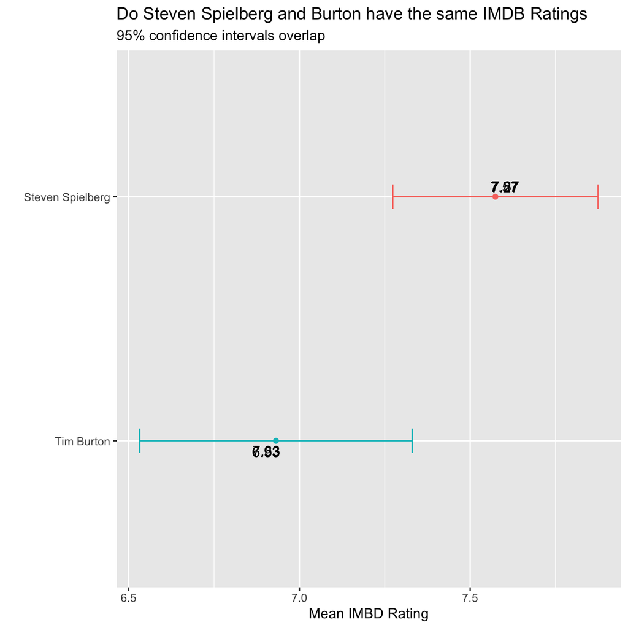

```r
ggplot(selected_directors,aes(x=avg,y=reorder(director,avg),color=director))+
  geom_errorbar(aes(xmin=lower_ci,xmax=upper_ci),width=0.1)+
  #Problem with this code; not plotting the labels at the extremes; where they should be for upper and lower boundaries
 ggrepel::geom_text_repel(aes(label = round(lower_ci, 2)), color = "black") +
  ggrepel::geom_text_repel(aes(label = round(upper_ci, 2)), color = "black") +labs(title="Do Steven Spielberg and Burton have the same IMDB Ratings",subtitle="95% confidence intervals overlap",x="Mean IMBD Rating",y="")+geom_point()+ggrepel::geom_text_repel(aes(label = round(avg, 2)), color = "black") +
  theme(legend.position = "none")
```

# 3 Omega Group plc- Pay Discrimination

At the last board meeting of Omega Group Plc., the headquarters of a large multinational company, the issue was raised that women were being discriminated in the company, in the sense that the salaries were not the same for male and female executives. A quick analysis of a sample of 50 employees (of which 24 men and 26 women) revealed that the average salary for men was about 8,700 higher than for women. This seemed like a considerable difference, so it was decided that a further analysis of the company salaries should be conducted.

Our team carried out the analysis to find out whether there is indeed a significant difference between the salaries of men and women, and whether the difference is due to discrimination or whether it is based on another, possibly valid, determining factor.

## 3.1 Loading the data

```r
omega <- read_csv(here::here("data", "omega.csv"))
glimpse(omega) # examine the data frame
```

```
## Rows: 50
## Columns: 3
## $ salary     <dbl> 81894, 69517, 68589, 74881, 65598, 76840, 78800, 70033, 63…
## $ gender     <chr> "male", "male", "male", "male", "male", "male", "male", "m…
## $ experience <dbl> 16, 25, 15, 33, 16, 19, 32, 34, 1, 44, 7, 14, 33, 19, 24, …
```

## 3.2 Relationship Salary - Gender ?

The data frame `omega` contains the salaries for the sample of 50 executives in the company. Is it possible to conclude that there is a significant difference between the salaries of the male and female executives?

To answer the question, we will start by analysing the key statistical parameters: mean, SD, sample size, confidence interval…

```r
# Summary Statistics of salary by gender
mosaic::favstats (salary ~ gender, data=omega)
```

```
##   gender   min    Q1 median    Q3   max  mean   sd  n missing
## 1 female 47033 60338  64618 70033 78800 64543 7567 26       0
## 2   male 54768 68331  74675 78568 84576 73239 7463 24       0
```

```r
# Dataframe with two rows (male-female) and having as columns gender, mean, SD, sample size,
# the t-critical value, the standard error, the margin of error,
# and the low/high endpoints of a 95% confidence interval
statistics<-omega%>%
select(salary,gender)%>%
  group_by(gender)%>%
  summarise(mean=mean(salary),SD=sd(salary),SampleSize=n(),t_crit=qt(0.975,SampleSize-1),SE=SD/sqrt(SampleSize),
            MarginError=t_crit*SE,LowBound=mean-MarginError,HighBound=mean+MarginError)
statistics
```

```
## # A tibble: 2 x 9
##   gender   mean    SD SampleSize t_crit    SE MarginError LowBound HighBound
##   <chr>   <dbl> <dbl>      <int>  <dbl> <dbl>       <dbl>    <dbl>     <dbl>
## 1 female 64543. 7567.         26   2.06 1484.       3056.   61486.    67599.
## 2 male   73239. 7463.         24   2.07 1523.       3151.   70088.    76390.
```

From the data obtained, we can observe that the confidence intervals do not overlap. Hence, we can conclude that there is a significant difference between the salaries of male and female executives.

Additionally, we will run further tests to verify our conclusion: a hypothesis testing, assuming a null hypothesis that the mean difference in salaries for mean and women is zero.

```r
# Hypothesis testing using t.test()
t.test(salary ~ gender, data = omega)
```

```
##
##  Welch Two Sample t-test
##
## data:  salary by gender
## t = -4, df = 48, p-value = 2e-04
## alternative hypothesis: true difference in means is not equal to 0
## 95 percent confidence interval:
##  -12973  -4420
## sample estimates:
## mean in group female   mean in group male
##                64543                73239
```

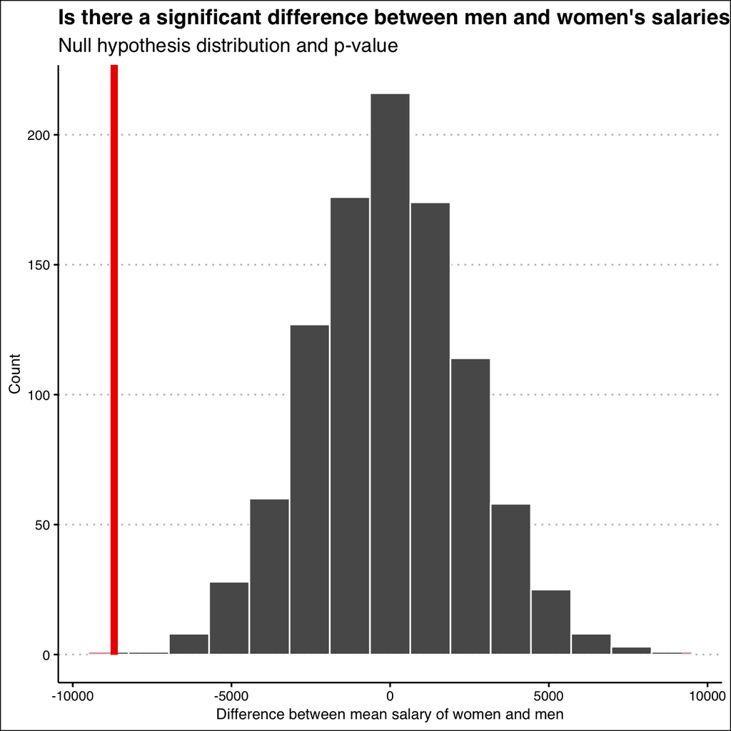

```r
# Hypothesis testing using infer package

#Initialize the test
init_sal_null<-omega%>%
specify(salary ~ gender)%>%
calculate(stat="diff in means",order=c("female","male"))
#Simulate the test on the null distribution, which we will save as null
salaries_null_world<-omega%>%
  specify(salary ~ gender)%>%
  hypothesize(null="independence")%>%
  generate(reps=1000,type="permute")%>%
  calculate(stat="diff in means",order=c("female","male"))
#Visualize the null distribution and get the p value
salaries_null_world %>% visualize() +
  shade_p_value(obs_stat = init_sal_null, direction = "two-sided")+
  #Customize the plot
  labs(x="Difference between mean salary of women and men",y="Count",title="Is there a significant difference between men and women's salaries?",subtitle="Null hypothesis distribution and p-value")+theme_clean()
```

```r
#Get the numerical value for p
salaries_null_world %>% get_p_value(obs_stat = init_sal_null, direction = "two_sided")
```

```
## # A tibble: 1 x 1
##   p_value
##     <dbl>
## 1       0
```

## 3.3 Relationship Experience - Gender?

At the board meeting, someone raised the issue that there was indeed a substantial difference between male and female salaries, but that this was attributable to other reasons such as differences in experience. A questionnaire send out to the 50 executives in the sample reveals that the average experience of the men is approximately 21 years, whereas the women only have about 7 years experience on average. The relevant statistical information is shown in the tables below.

```r
# Summary Statistics of experience by gender
favstats (experience ~ gender, data=omega)
```

```
##   gender min    Q1 median   Q3 max  mean    sd  n missing
## 1 female   0  0.25    3.0 14.0  29  7.38  8.51 26       0
## 2   male   1 15.75   19.5 31.2  44 21.12 10.92 24       0
```

```r
#Calculate additional key statistics and confidence intervals
statistics<-omega%>%
select(experience,gender)%>%
  group_by(gender)%>%
  summarise(mean=mean(experience),SD=sd(experience),SampleSize=n(),t_critical=qt(0.975,SampleSize-1),SE=SD/sqrt(SampleSize),
  MarginError=t_critical*SE,LowEndpoint=mean-MarginError,HighEndpoint=mean+MarginError)
statistics
```

```
## # A tibble: 2 x 9
##   gender  mean    SD SampleSize t_critical    SE MarginError LowEndpoint
##   <chr>  <dbl> <dbl>      <int>      <dbl> <dbl>       <dbl>       <dbl>
## 1 female  7.38  8.51         26       2.06  1.67        3.44        3.95
## 2 male   21.1  10.9          24       2.07  2.23        4.61       16.5
## # … with 1 more variable: HighEndpoint <dbl>
```

The confidence intervals do not overlap. Hence, we can conclude that there is a significant difference in the experience of female and male executives. Further tests based on null hypothesis are conducted below.

```r
# Hypothesis testing using t.test()
t.test(experience ~ gender, data = omega)
```

```
##
##  Welch Two Sample t-test
##
## data:  experience by gender
## t = -5, df = 43, p-value = 1e-05
## alternative hypothesis: true difference in means is not equal to 0
## 95 percent confidence interval:
##  -19.35  -8.13
## sample estimates:
## mean in group female   mean in group male
##                 7.38                21.12
```

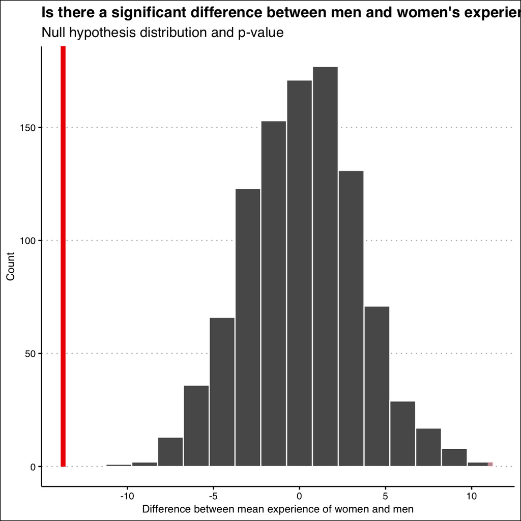

```r
# Hypothesis testing using infer package
#Initialize the test
init_exp_null <- omega %>%
specify(experience ~ gender)%>%
calculate(stat="diff in means",order=c("female","male"))

#Simulate the test on the null distribution, which we will save as experience_null_world
experience_null_world <- omega %>%
  specify(experience ~ gender) %>%
  hypothesize(null="independence") %>%
  generate(reps=1000,type="permute") %>%
  calculate(stat="diff in means",order=c("male","female"))

#Visualize the null distribution and get the p value
experience_null_world %>% visualize() +
  shade_p_value(obs_stat = init_exp_null, direction = "two-sided")+
  #Customize the plot
  labs(x="Difference between mean experience of women and men",y="Count",title="Is there a significant difference between men and women's experience?",subtitle="Null hypothesis distribution and p-value")+theme_clean()
```

```r
#Get the numerical p value
experience_null_world %>% get_p_value(obs_stat = init_exp_null, direction = "two_sided")
```

```
## # A tibble: 1 x 1
##   p_value
##     <dbl>
## 1       0
```

From the data obtained using t.test(), the plot of the null distribution and the p value (which is less than 0.05), we can reject the null hypothesis.Hence, we can conclude that there is a significant difference between the experience of men and women. This conclusion doesn’t endanger the previous one that indicated that salaries of men and women are significantly different. However, from the current analysis, we can say the salaries are not necessarily different due to factors such as gender discrimination, there can be other factors such as experience having an important effect on the salary gap.

## 3.4 Relationship Salary - Experience ?

Someone at the meeting argues that clearly, a more thorough analysis of the relationship between salary and experience is required before any conclusion can be drawn about whether there is any gender-based salary discrimination in the company.

Analyse the relationship between salary and experience. Draw a scatterplot to visually inspect the data

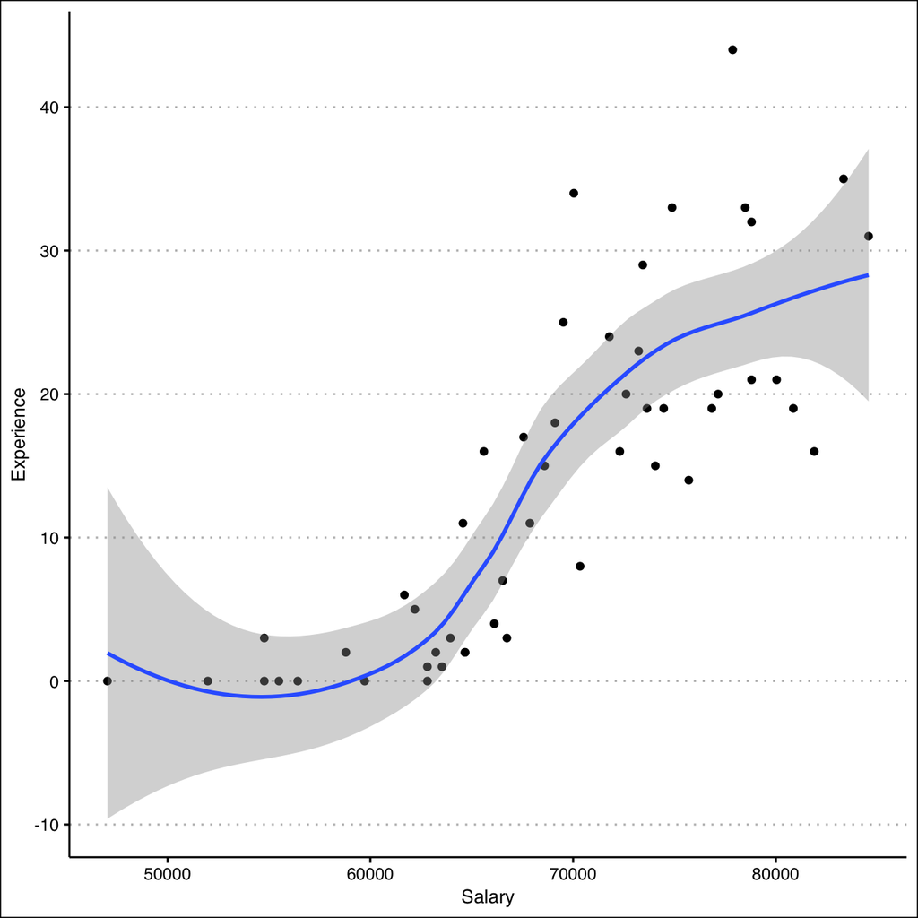

```r
ggplot(data=omega, aes(x=salary,y=experience))+geom_point()+labs(x="Salary",y="Experience")+geom_smooth()+theme_clean()
```

## 3.5 Check correlations between the data

You can use `GGally:ggpairs()` to create a scatterplot and correlation matrix. Essentially, we change the order our variables will appear in and have the dependent variable (Y), salary, as last in our list. We then pipe the dataframe to `ggpairs()` with `aes` arguments to colour by `gender` and make ths plots somewhat transparent (`alpha = 0.3`).

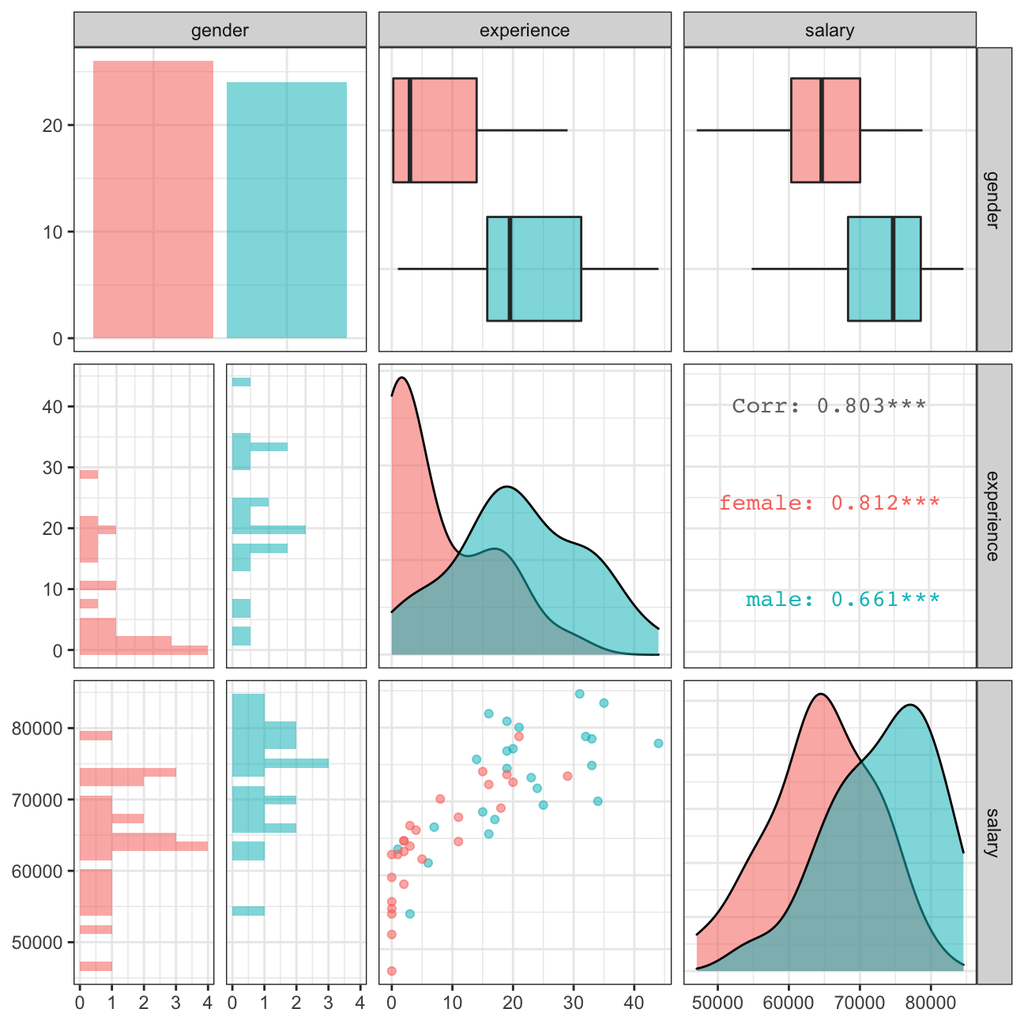

```r
omega %>%
  select(gender, experience, salary) %>% #order variables they will appear in ggpairs()
  ggpairs(aes(colour=gender, alpha = 0.3))+
  theme_bw()
```

> Look at the salary vs experience scatterplot. What can you infer from this plot? Explain in a couple of sentences

# 4 Challenge 1: Brexit plot

Using your data manipulation and visualisation skills, please use the Brexit results dataframe (the same dataset you used in the pre-programme assignement) and produce the following plot. Use the correct colour for each party; google “UK Political Party Web Colours” and find the appropriate hex code for colours, not the default colours that R gives you.

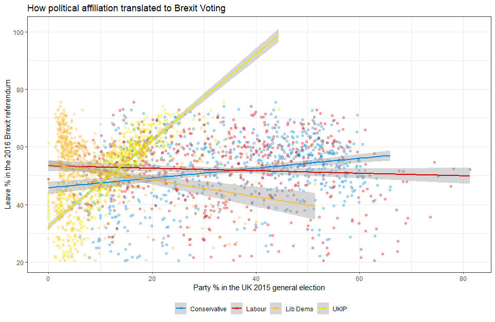